# Chap 5: The Grammar of Graphics: The ggplot2 Package

jharner

February 4, 2015

The `ggplot2` package provides an interpretation and extension of the ideas in Leland Wilkinson’s book *The Grammar of Graphics*. The `ggplot2` package represents a complete and coherent graphics system, completely separate from both traditional and lattice graphics.

The `ggplot2` package is built on `grid`, so it provides another way to generate complete plots within the grid world.

## 5.1 Quick plots

For very simple plots, the `qplot()` function in `ggplot2` serves a similar purpose to the `plot()` function in traditional graphics.

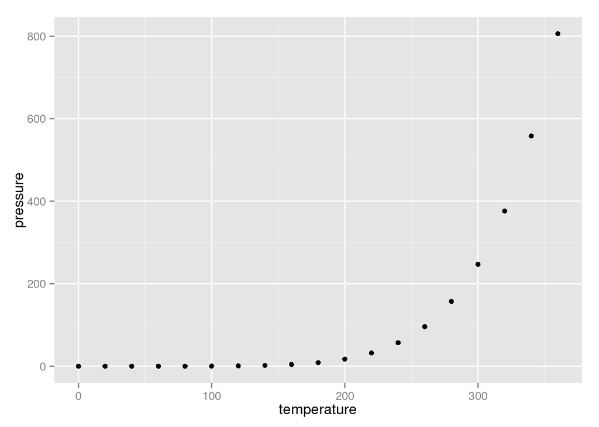

```r
library(ggplot2)
qplot(temperature, pressure, data=pressure)
```

The main differences between this scatterplot and what is produced by the traditional plot() function are just the default settings.

There are similarities in how the appearance of the plot can be modified.

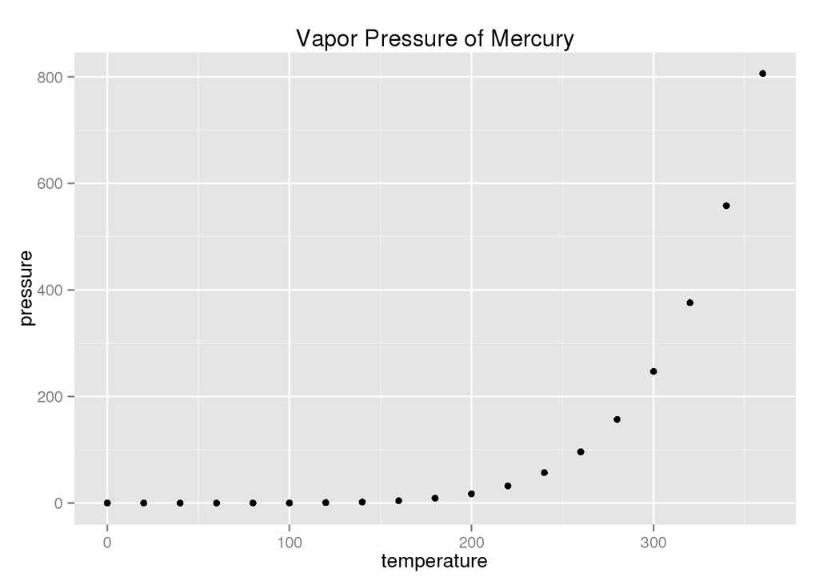

```r
qplot(temperature, pressure, data=pressure, main="Vapor Pressure of Mercury")
```

`ggplot2` diverges quite rapidly from the other graphics systems if further customizations are desired.

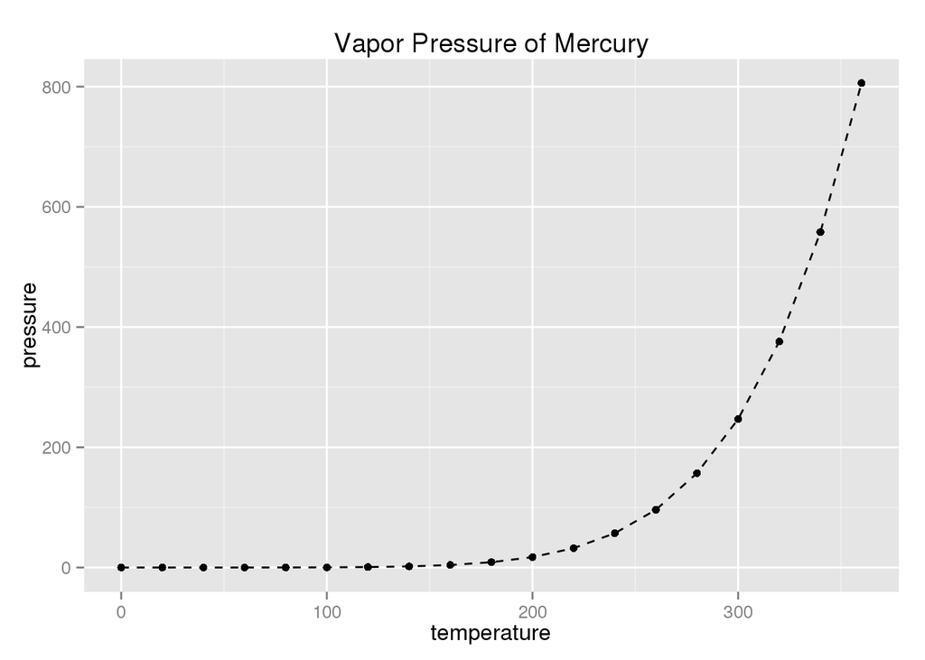

```r
qplot(temperature, pressure, data=pressure,
      main="Vapor Pressure of Mercury",
      geom=c("point", "line"), lty=I("dashed"))
```

The `lty` argument in this code is familiar, but the value “dashed” is wrapped inside a call to the `I()` function. The `geom` argument is also unique to `ggplot2`.

The `diamonds` dataset consists of prices and quality information about 54,000 diamonds, and is included in the `ggplot2` package. The data contains the four C’s of diamond quality (`carat`, `cut`, `colour` and `clarity`) and five physical measurements (`depth`, `table`, `x`, `y` and `z`).

```r
library(ggplot2)
data(diamonds)
head(diamonds)
```

```
##   carat       cut color clarity depth table price    x    y    z
## 1  0.23     Ideal     E     SI2  61.5    55   326 3.95 3.98 2.43
## 2  0.21   Premium     E     SI1  59.8    61   326 3.89 3.84 2.31
## 3  0.23      Good     E     VS1  56.9    65   327 4.05 4.07 2.31
## 4  0.29   Premium     I     VS2  62.4    58   334 4.20 4.23 2.63
## 5  0.31      Good     J     SI2  63.3    58   335 4.34 4.35 2.75
## 6  0.24 Very Good     J    VVS2  62.8    57   336 3.94 3.96 2.48
```

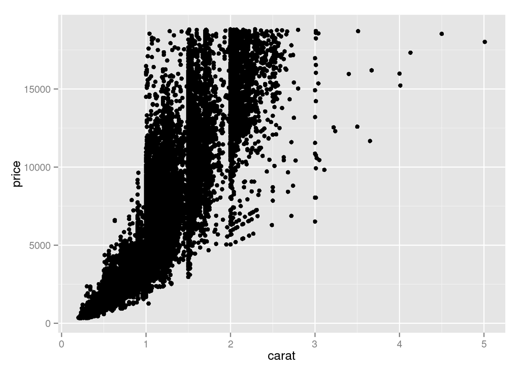

```r
qplot(carat, price, data = diamonds)
```

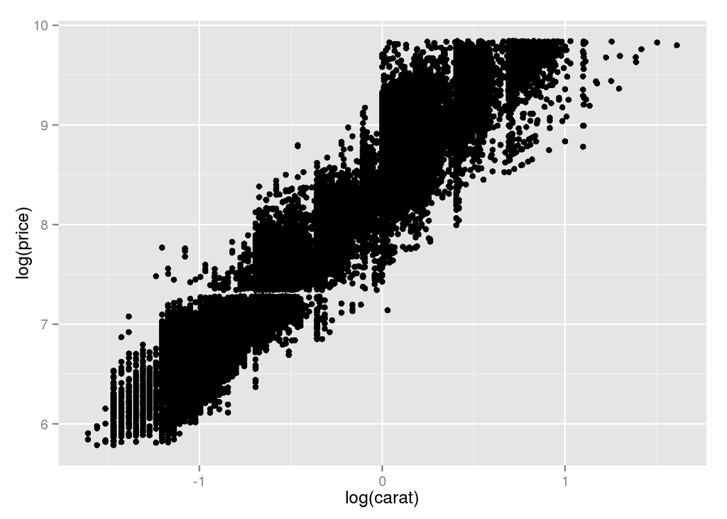

```r
qplot(log(carat), log(price), data = diamonds)
```

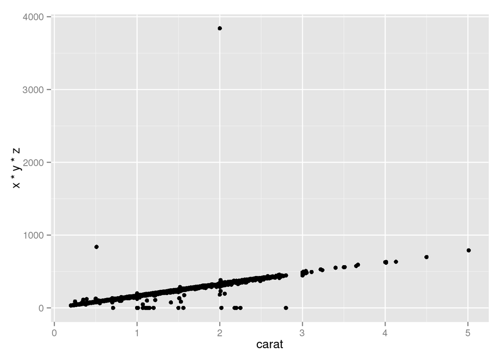

```r
qplot(carat, x * y * z, data = diamonds)
```

#### Plots of carat and price with information about diamond colour and cut.

```r
set.seed(1410)
dsmall <- diamonds[sample(nrow(diamonds), 100), ]
head(dsmall)
```

```
##       carat     cut color clarity depth table price    x    y    z
## 14513  1.35   Ideal     J     VS2  61.4    57  5862 7.10 7.13 4.37
## 28685  0.30    Good     G    VVS1  64.0    57   678 4.23 4.27 2.72
## 50368  0.75   Ideal     F     SI2  59.2    60  2248 5.87 5.92 3.49
## 7721   0.26   Ideal     F     VS1  60.9    57   580 4.13 4.11 2.51
## 31082  0.33 Premium     H    VVS1  61.4    59   752 4.42 4.44 2.72
## 26429  1.52   Ideal     G    VVS1  62.4    55 15959 7.30 7.39 4.58
```

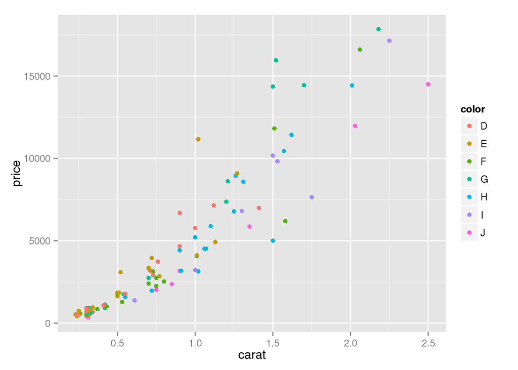

```r
qplot(carat, price, data = dsmall, colour = color)
```

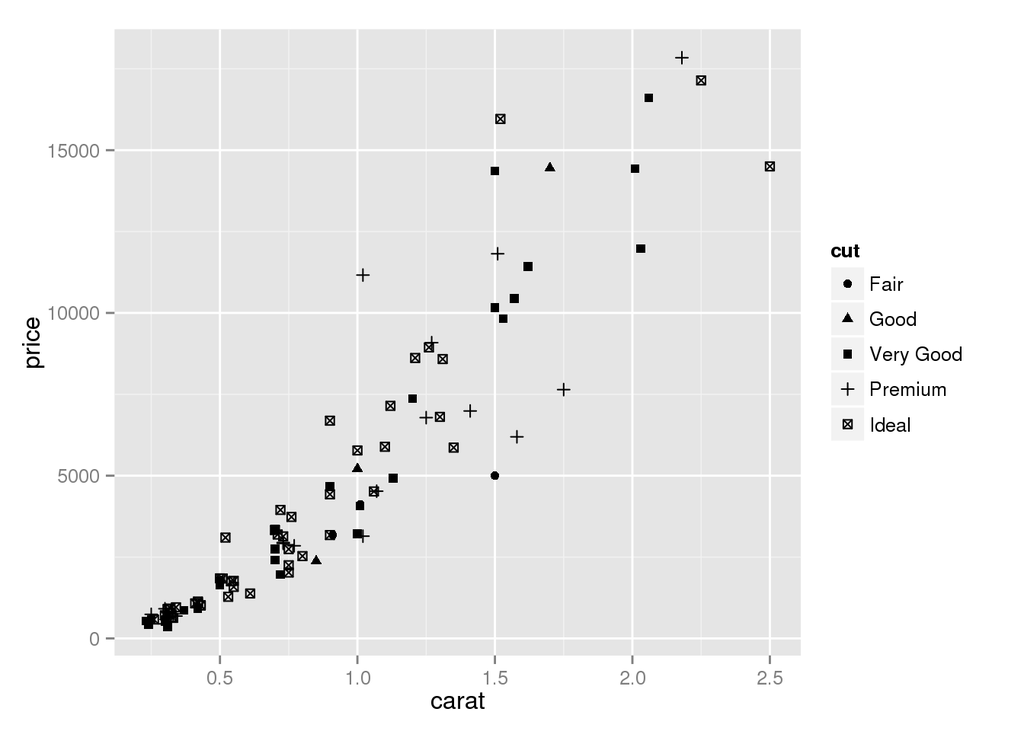

```r
qplot(carat, price, data = dsmall, shape = cut)
```

Colour, size and shape are all examples of aesthetic attributes, visual properties that affect the way observations are displayed. For every aesthetic attribute, there is a function, called a `scale`, which maps data values to valid values for that aesthetic.

You can also manually set the aesthetics using `I()`, e.g., `colour = I("red")`.

To make a semi-transparent colour you can use the `alpha` aesthetic, which takes a value between 0 (completely transparent) and 1 (complete opaque).

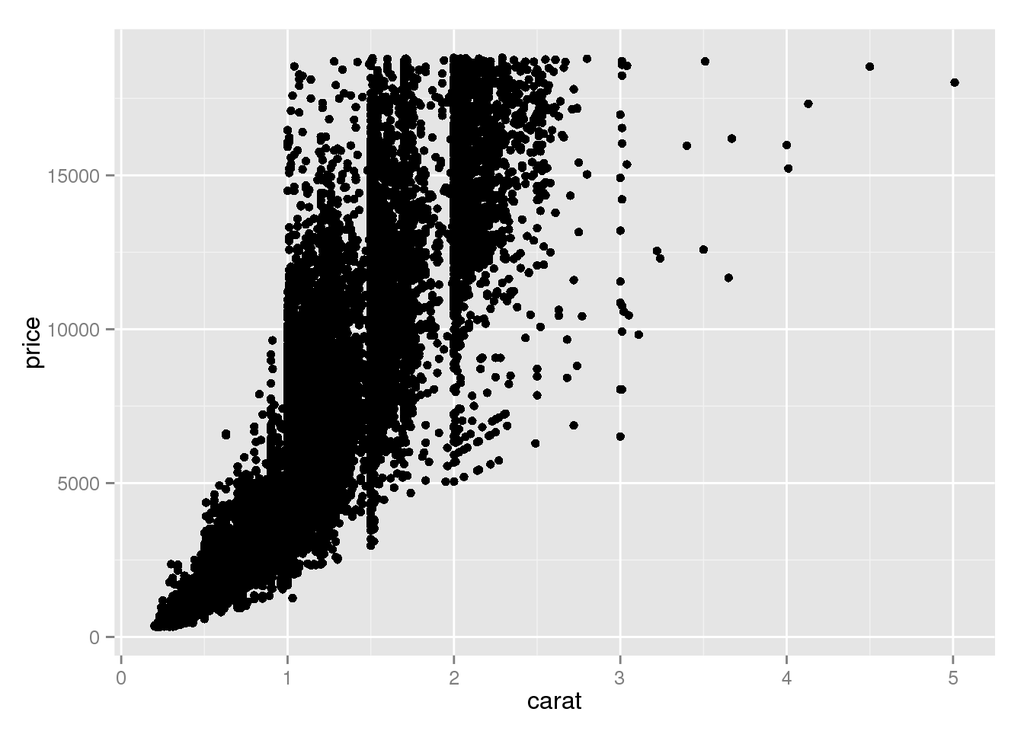

```r
qplot(carat, price, data = diamonds)
```

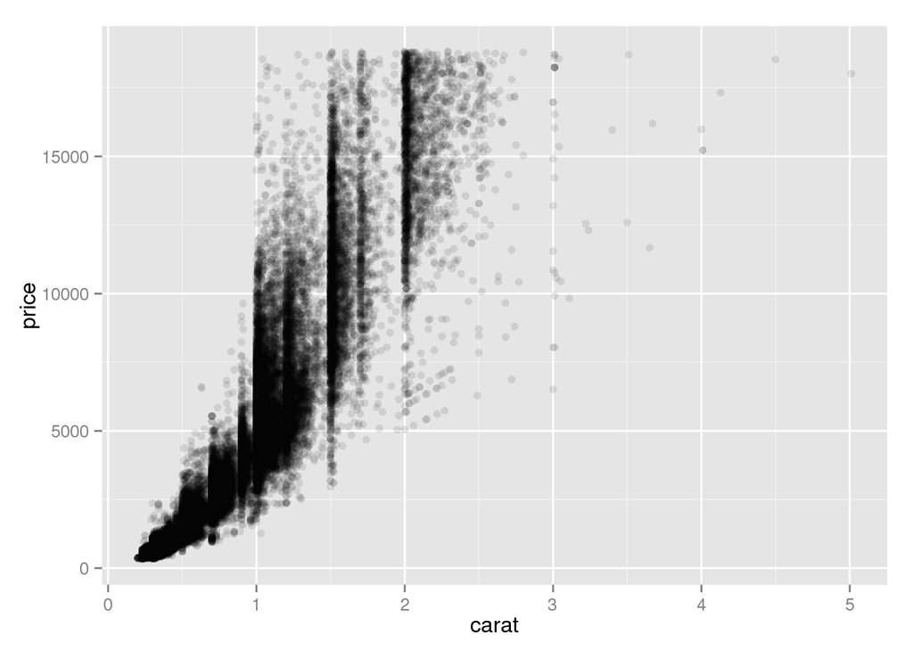

```r
qplot(carat, price, data = diamonds, alpha = I(1/10))
```

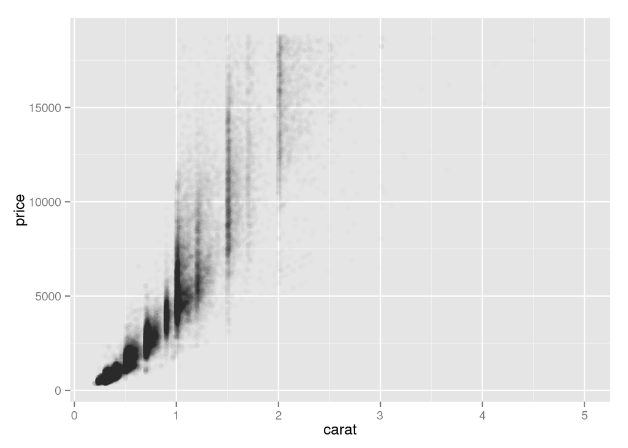

```r
qplot(carat, price, data = diamonds, alpha = I(1/100))
```

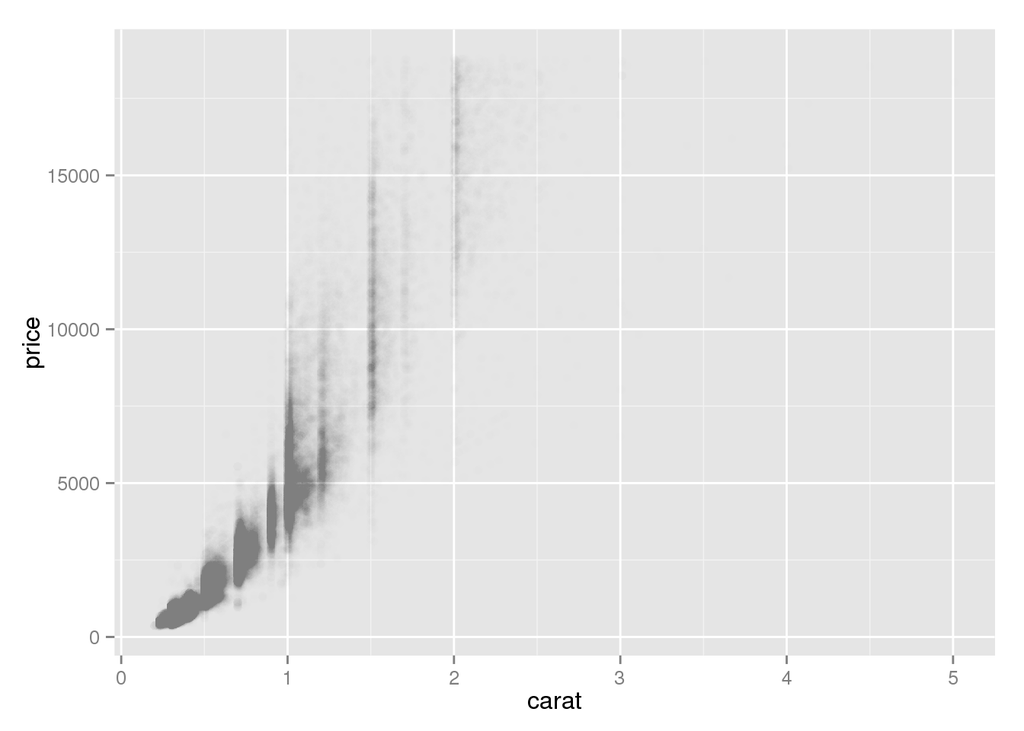

```r
qplot(carat, price, data = diamonds, alpha = I(1/200))
```

#### Plot geoms

`qplot` is not limited to scatterplots, but can produce almost any kind of plot by varying the `geom`. Geom (short for geometric object) describes the type of object that is used to display the data. Some geoms have an associated statistical transformation.

The following geoms illustrate:  
* `geom = "point"` draws points to produce a scatterplot. This is the default when you supply both `x` and `y` arguments to `qplot()`.  
* geom = “smooth” fits a smoother to the data and displays the smooth and its standard error.

#### Adding a smoother to a plot

If you have a scatterplot with many data points, it can be hard to see exactly what trend is shown by the data. In this case you may want to add a smoothed line to the plot. This is easily done using the smooth geom.

```
## geom_smooth: method="auto" and size of largest group is <1000, so using loess. Use 'method = x' to change the smoothing method.
```

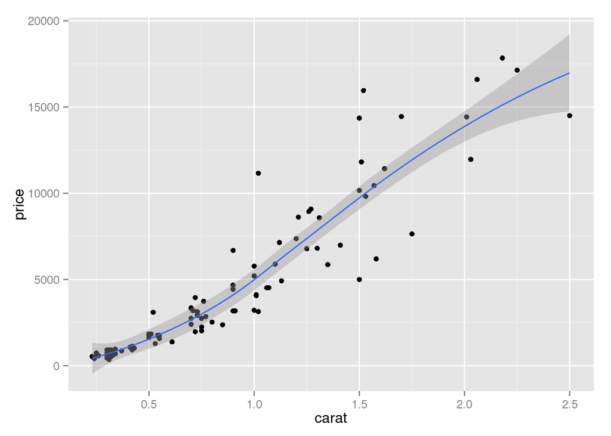

```r
qplot(carat, price, data = dsmall, geom = c("point", "smooth"))
```

```
## geom_smooth: method="auto" and size of largest group is >=1000, so using gam with formula: y ~ s(x, bs = "cs"). Use 'method = x' to change the smoothing method.
```

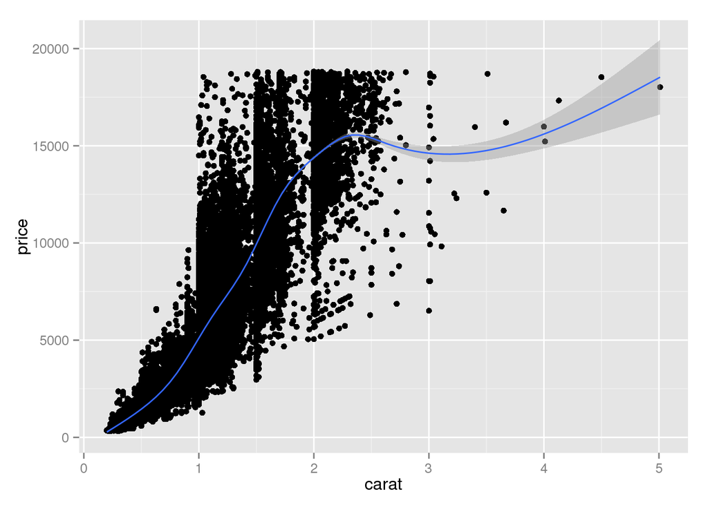

```r
qplot(carat, price, data = diamonds, geom = c("point", "smooth"))
```

The default smoother uses `method = "loess"` for small n, a smooth local regression.

The wiggliness of the line is controlled by the `span` parameter, which ranges from 0 (exceedingly wiggly) to 1 (not so wiggly).

```
## geom_smooth: method="auto" and size of largest group is <1000, so using loess. Use 'method = x' to change the smoothing method.
```

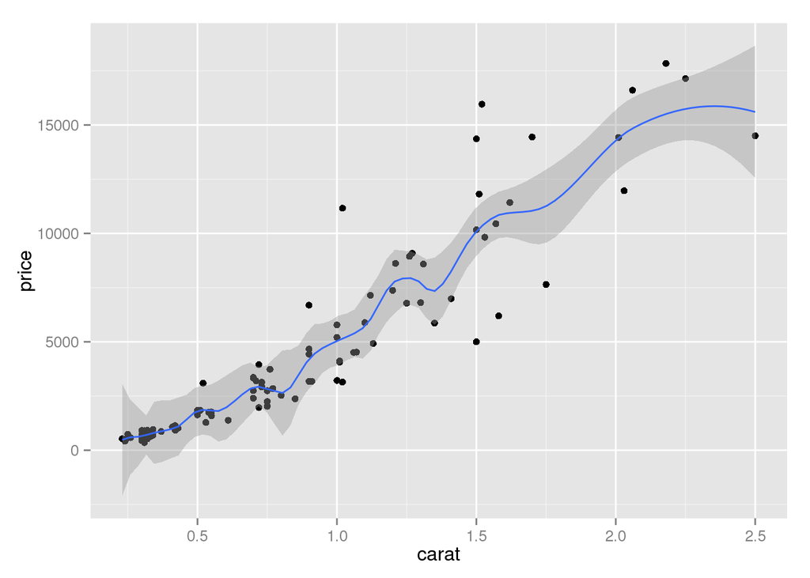

```r
qplot(carat, price, data = dsmall, geom = c("point", "smooth"), span = 0.2)
```

```
## geom_smooth: method="auto" and size of largest group is <1000, so using loess. Use 'method = x' to change the smoothing method.
```

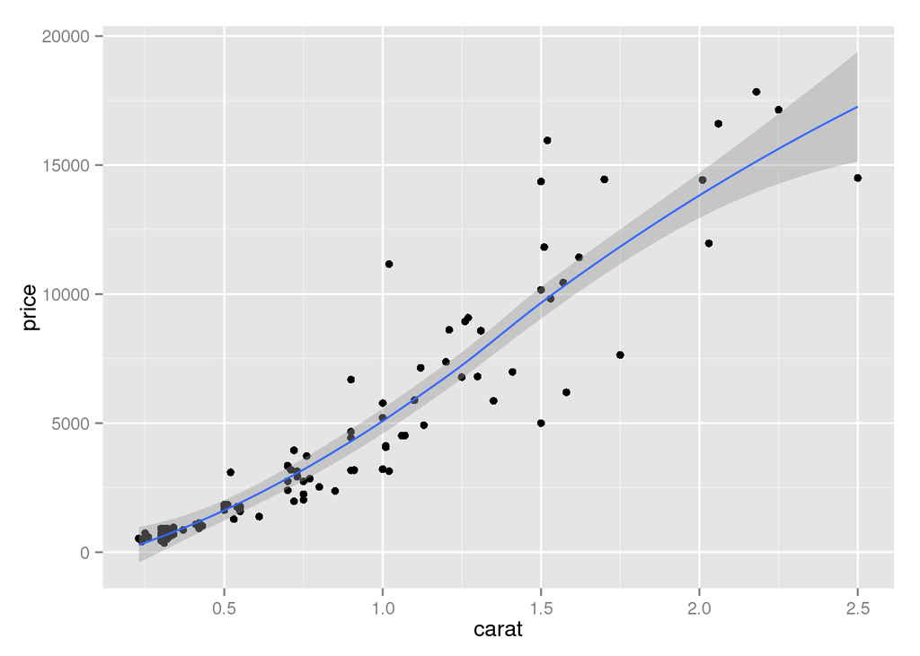

```r
qplot(carat, price, data = dsmall, geom = c("point", "smooth"), span = 1)
```

Loess does not work well for large datasets (it’s $O(n^2)$ in memory), and so an alternative smoothing algorithm is used when $n$ is greater than 1,000.

Use the `mgcv` library and use `method = "gam", formula = y ∼ s(x)` to fit a generalized additive model. This is similar to using a spline with `lm`, but the degree of smoothness is estimated from the data. For large data, use the formula `y ~ s(x, bs = "cs")`. This is used by default when there are more than 1,000 points.

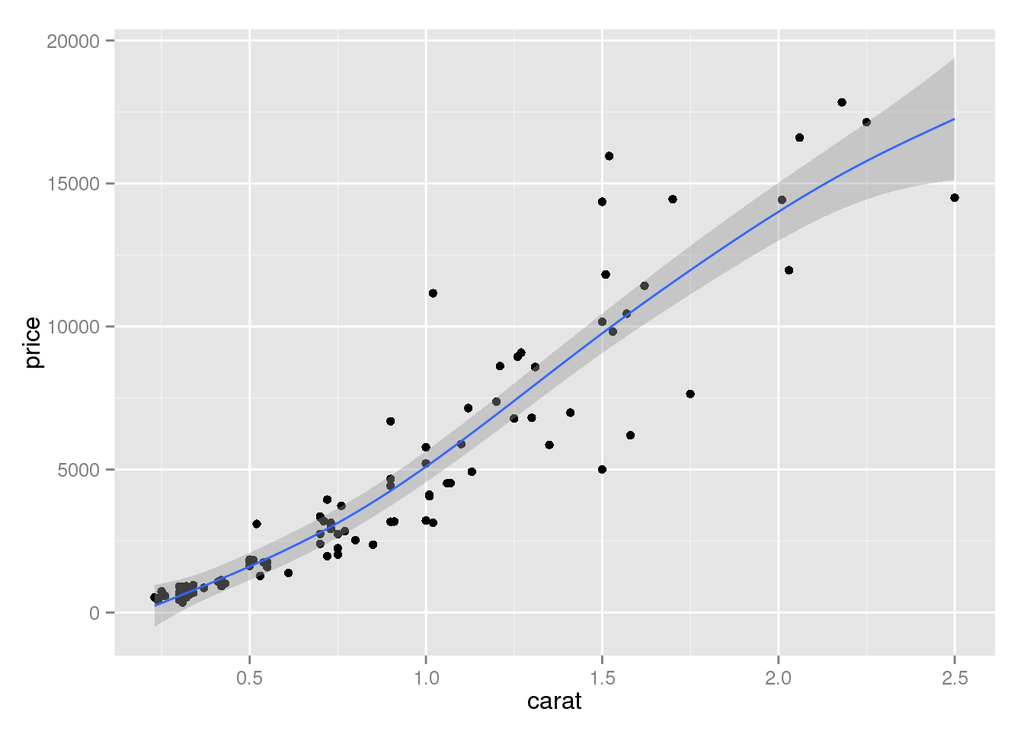

```r
library(mgcv)
qplot(carat, price, data = dsmall, geom = c("point", "smooth"),
      method = "gam", formula = y ~ s(x))
```

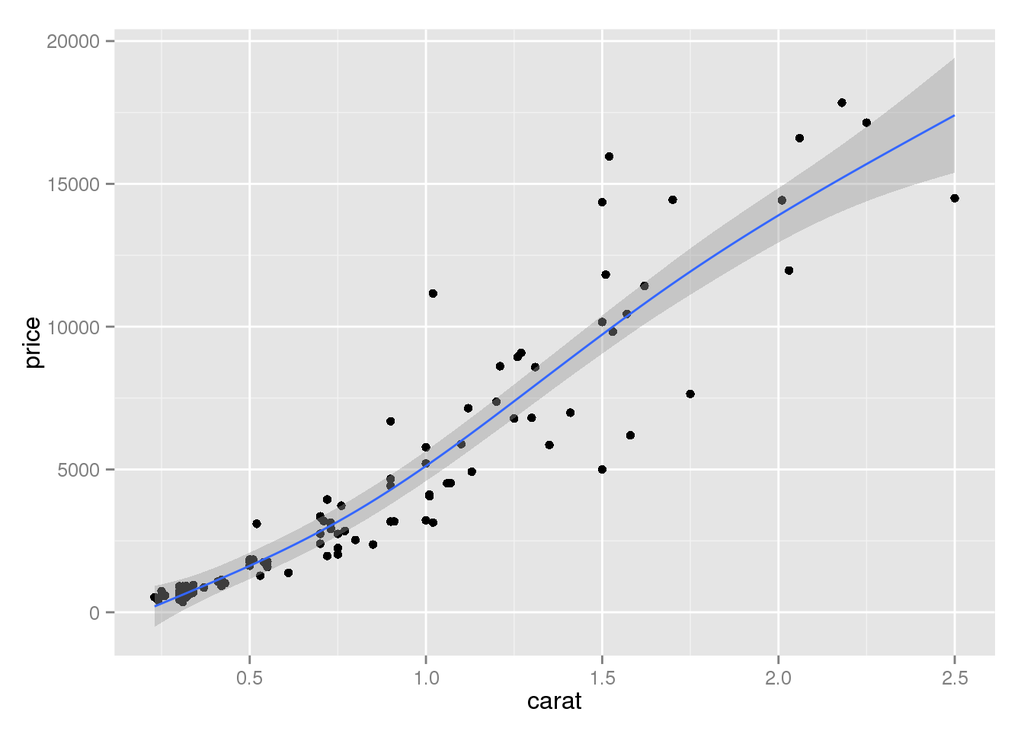

```r
qplot(carat, price, data = dsmall, geom = c("point", "smooth"),
      method = "gam", formula = y ~ s(x, bs = "cs"))
```

`method = "lm"` fits a linear model. The default will fit a straight line to your data, or you can specify `formula = y ~ poly(x, 2)` to specify a degree 2 polynomial. Load the `splines` package and use a natural spline: `formula = y ~ ns(x, 2)`. The second parameter is the degrees of freedom: a higher number will create a wigglier curve. You are free to specify any formula involving `x` and `y`.

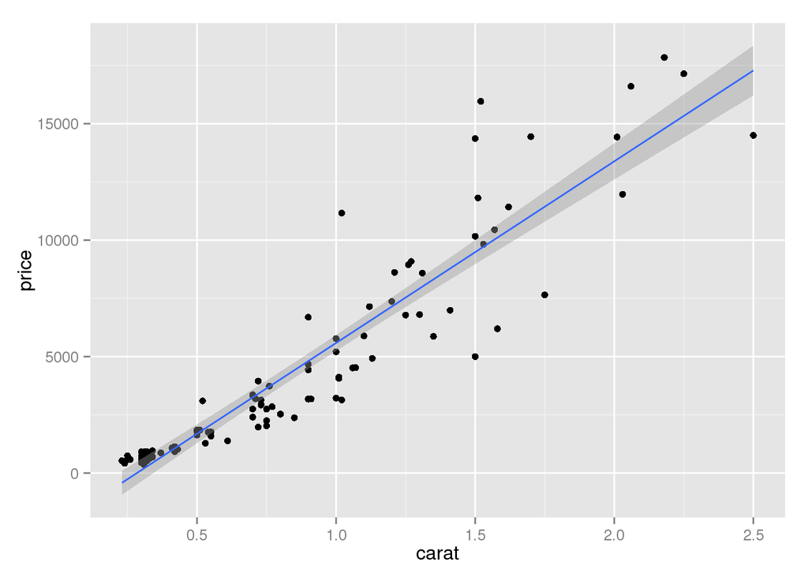

```r
library(splines)
qplot(carat, price, data = dsmall, geom = c("point", "smooth"), method = "lm")
```

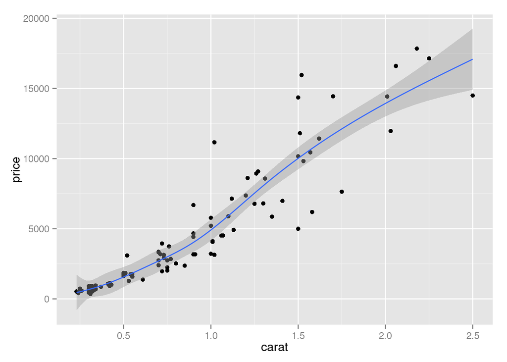

```r
qplot(carat, price, data = dsmall, geom = c("point", "smooth"),
      method = "lm", formula = y ~ ns(x,5))
```

## 5.2 The ggplot2 graphics model

The `ggplot2` package implements the Grammar of Graphics paradigm. Rather than having lots of different functions, each of which produces a different sort of plot, there is a small set of functions, each of which produces a different sort of plot component, and those components can be combined in many different ways to produce a huge variety of plots.

The steps in creating a plot with `ggplot2`:  
* Define the data that you want to plot and create an empty plot object with `ggplot()`.  
* Specify what graphics shapes, or *geoms*, that you are going to use to view the data (e.g., data symbols or lines) and add those to the plot with, for example, `geom_point()` or `geom_line()`.  
* Specify which features, or *aesthetics*, of the shapes will be used to represent data values (e.g., the x- and y-locations of data symbols) with the `aes()` function.

The data set is the `pressure` data frame, and the variables `temperature` and `pressure` are used as the x and y locations of data symbols.

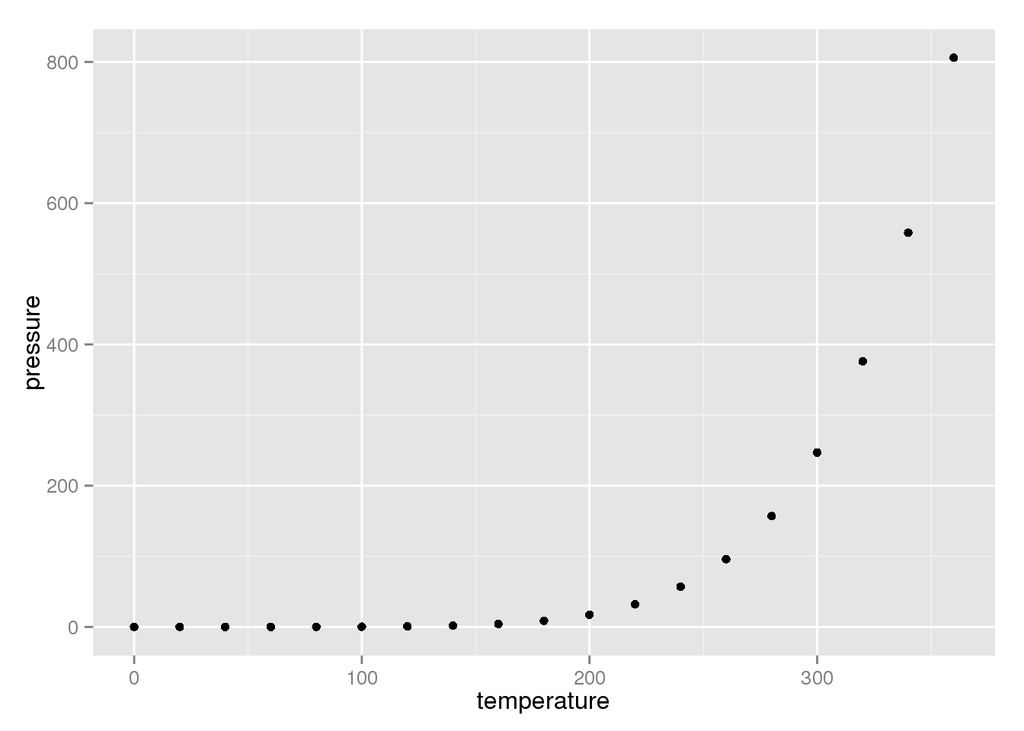

```r
ggplot(pressure) +
  geom_point(aes(x=temperature, y=pressure))
```

A `ggplot2` plot is built up like this by creating plot components, or layers, and combining them using the `+` operator.

### 5.2.1 Why another graphics system

Reasons for using `ggplot2` over lattice and traditional graphics:  
* the default appearance of plots has been carefully chosen with visual perception in mind;  
* the arrangement of plot components and the inclusion of legends is automated;  
* the language is powerful and concise for expressing a variety of plots;  
* rendering is done with `grid`, providing flexibility for annotating, editing, and embedding `ggplot2` output.

### 5.2.2 An example data set

The `mtcars2` data set is based on the `mtcars` data set from the `datasets` package and contains information on 32 different car models, including:  
* the size of the car engine (`disp`)  
* the fuel efficiency (`mpg`)  
* type of transmission (`trans`)  
* number of forward gears (`gear`)  
* number of cylinders (cyl).

```r
mtcars2 <- mtcars
mtcars2$trans <- factor(mtcars$am,
                        levels=0:1,
                        labels=c("automatic", "manual"))
head(mtcars2)
```

```
##                    mpg cyl disp  hp drat    wt  qsec vs am gear carb
## Mazda RX4         21.0   6  160 110 3.90 2.620 16.46  0  1    4    4
## Mazda RX4 Wag     21.0   6  160 110 3.90 2.875 17.02  0  1    4    4
## Datsun 710        22.8   4  108  93 3.85 2.320 18.61  1  1    4    1
## Hornet 4 Drive    21.4   6  258 110 3.08 3.215 19.44  1  0    3    1
## Hornet Sportabout 18.7   8  360 175 3.15 3.440 17.02  0  0    3    2
## Valiant           18.1   6  225 105 2.76 3.460 20.22  1  0    3    1
##                       trans
## Mazda RX4            manual
## Mazda RX4 Wag        manual
## Datsun 710           manual
## Hornet 4 Drive    automatic
## Hornet Sportabout automatic
## Valiant           automatic
```